# qiime2R_tutorial_S2022_qCMB_day2

Heather Deel

2022-04-22

# As a reminder from the day 1 tutorial, here is our study design:

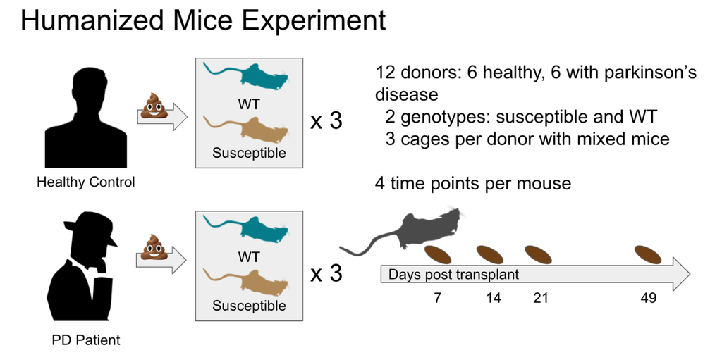

# Load in libraries:

```r
library(qiime2R)
library(tidyverse)
```

# Reimport our metadata and feature table into our environment (these are the same files as from day 1):

```r
metadata <- read_q2metadata("metadata.tsv")
SVs <- read_qza("table.qza")
```

After analyzing and doing statistics on alpha diversity, it is very common in microbiome analysis to next look at the beta diversity. While alpha diversity is a measure of microbiome diversity applicable to a single sample, beta diversity is a measure of similarity or dissimilarity of two communities. As a result, the output of beta diversity calculations is a distance matrix in which each number within the matrix represents the similarity or dissimilarity between two samples. These types of matrices are also referred to as resemblance matrices.

Like with alpha diversity, there are several different beta diversity metrics that we can and should look at in microbiome data analysis that will help to understand different things about the data. Here are some common ones:

1. Bray Curtis - non-phylogenetic, quantifies quantifies what features are shared between samples, weighted by feature abundance
2. Jaccard - non-phylogenetic, quantifies what features are shared between samples, not weighted by feature abundance
3. Unweighted UniFrac - phylogenetic, not weighted by feature abundance
4. Weighted UniFrac - phylogenetic, weighted by feature abundance

For each of these metrics, the PCoA results have been generated for you in QIIME2.

# Let’s import all of our PCoA results for the four metrics listed above using the read_qza function:

```r
bray_curtis <- read_qza("bray_curtis_pcoa_results.qza")
jaccard <- read_qza("jaccard_pcoa_results.qza")
unwe_unifrac <- read_qza("unweighted_unifrac_pcoa_results.qza")
we_unifrac <- read_qza("weighted_unifrac_pcoa_results.qza")
```

# Explore the bray curtis pcoa results

```r
bray_curtis$uuid #get the uuid associated with the bray curtis pcoa file
```

```
## [1] "9dd91907-92f1-4565-b96a-d932442bd8f3"
```

```r
head(bray_curtis$data$ProportionExplained) #look at the PC axes percentiles
```

```
##         PC1        PC2        PC3        PC4       PC5        PC6        PC7
## 1 0.5403785 0.08910927 0.07069755 0.04774566 0.0415934 0.02951473 0.02209521
##          PC8        PC9       PC10       PC11       PC12       PC13        PC14
## 1 0.01904523 0.01846576 0.01628313 0.01335602 0.01274764 0.01082625 0.009849509
##          PC15        PC16       PC17       PC18        PC19        PC20
## 1 0.009474449 0.008125882 0.00602261 0.00528062 0.004871338 0.004332572
##          PC21        PC22        PC23        PC24        PC25        PC26
## 1 0.003970682 0.003184554 0.002466986 0.002243614 0.002081972 0.001556755
##          PC27        PC28         PC29         PC30         PC31        PC32
## 1 0.001393175 0.001316304 0.0009476362 0.0007694479 0.0002472315 6.35865e-06
##   PC33 PC34 PC35 PC36 PC37 PC38 PC39 PC40 PC41 PC42 PC43 PC44 PC45 PC46 PC47
## 1    0    0    0    0    0    0    0    0    0    0    0    0    0    0    0
```

```r
bray_curtis$data$Vectors[1:5, 1:3] #for the first 5 samples, position along PC1 and PC2
```

```
##                SampleID        PC1         PC2
## 1   recip.220.WT.OB1.D7 -0.2769278  0.18459820
## 2  recip.290.ASO.OB2.D1 -0.3408401  0.18107094
## 3  recip.389.WT.HC2.D21 -0.3156983  0.02117448
## 4 recip.391.ASO.PD2.D14 -0.2735692 -0.07537573
## 5 recip.391.ASO.PD2.D21 -0.3306155 -0.01594040
```

# Make the Bray Curtis PCoA plot by genotype_and_donor_status

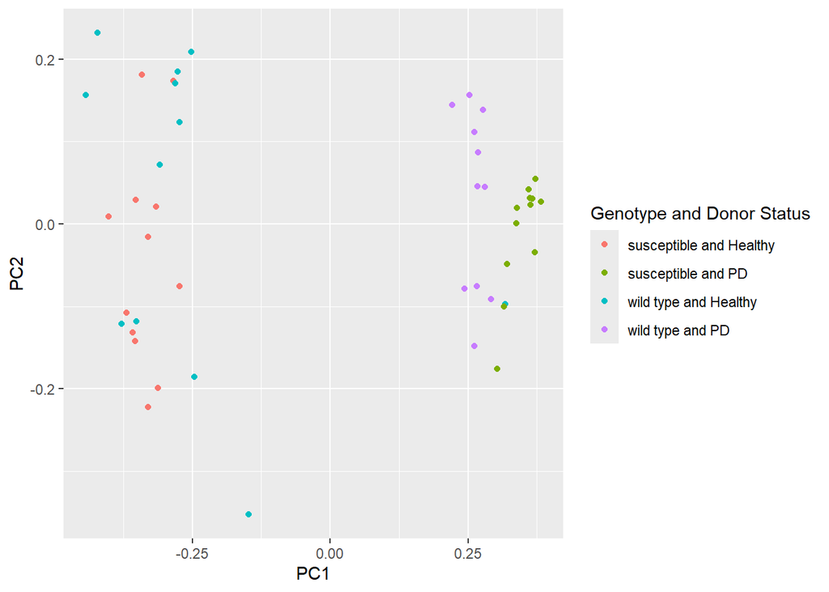

```r
bray_curtis$data$Vectors %>%
  select(SampleID, PC1, PC2) %>%
  left_join(metadata) %>%
  ggplot(aes(x=PC1, y=PC2, color=`genotype_and_donor_status`)) +
  geom_point() +
  #theme_q2r() +
  scale_color_discrete(name = "Genotype and Donor Status")
```

What kind of trend, or “clustering” do you see?

# Let’s make PCoA plots for each of the other discussed metrics. We can do these all in one code chunk, and then click the output boxes to see each of the plots.

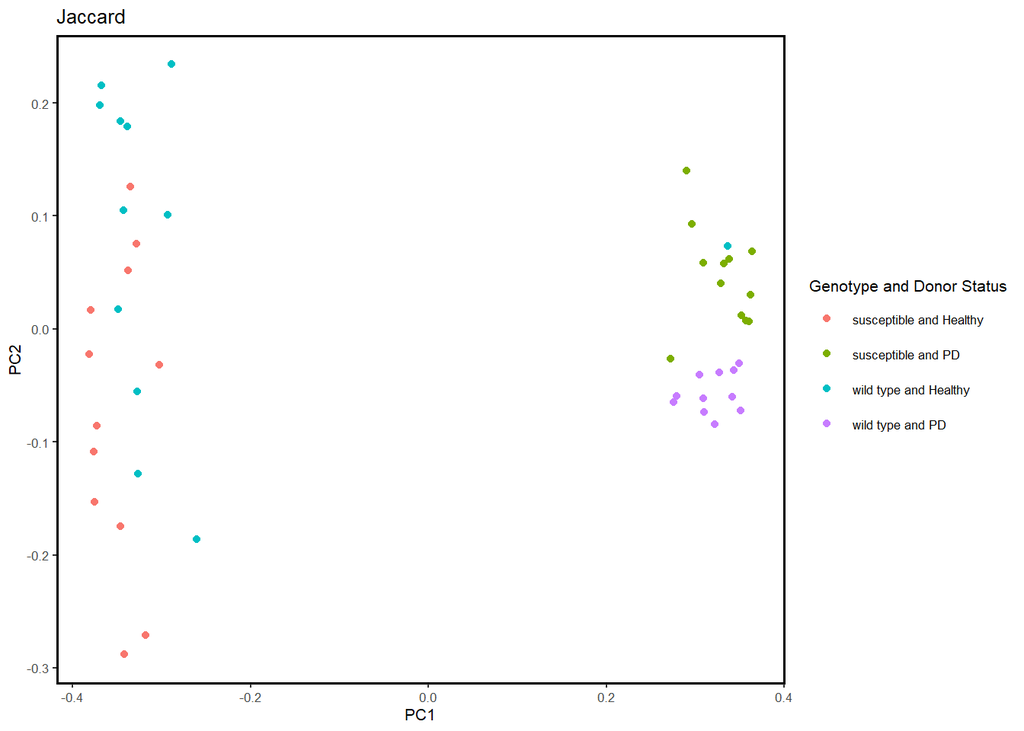

```r
jaccard$data$Vectors %>%
  select(SampleID, PC1, PC2) %>%
  left_join(metadata) %>%
  ggplot(aes(x=PC1, y=PC2, color=`genotype_and_donor_status`)) +
  geom_point() +
  theme_q2r() +
  ggtitle("Jaccard") +
  scale_color_discrete(name = "Genotype and Donor Status")
```

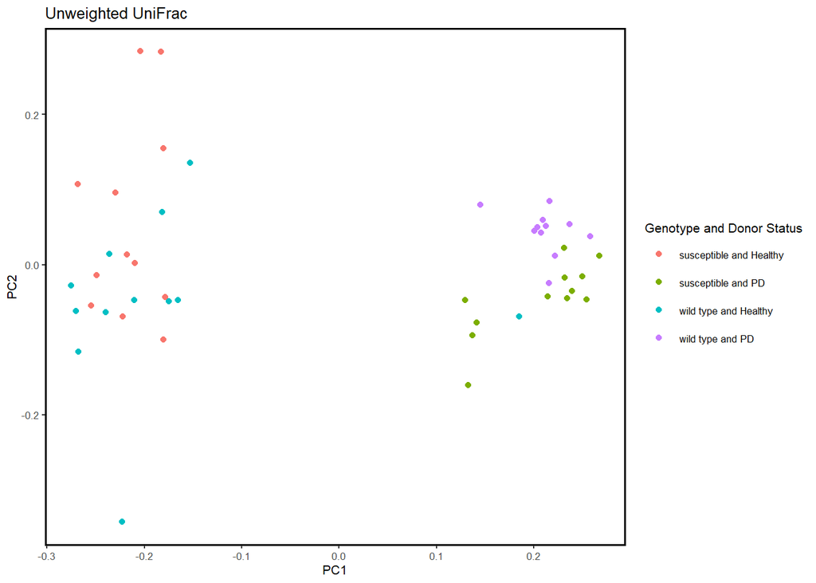

```r
unwe_unifrac$data$Vectors %>%
  select(SampleID, PC1, PC2) %>%
  left_join(metadata) %>%
  ggplot(aes(x=PC1, y=PC2, color=`genotype_and_donor_status`)) +
  geom_point() +
  theme_q2r() +
  ggtitle("Unweighted UniFrac") +
  scale_color_discrete(name = "Genotype and Donor Status")
```

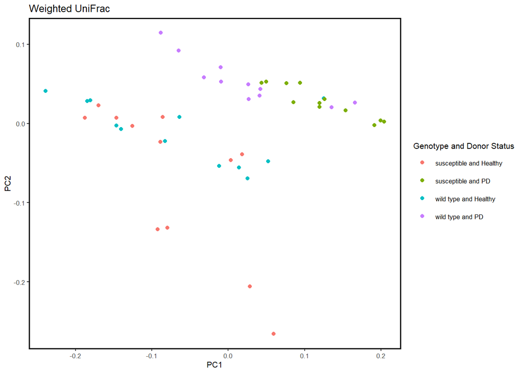

```r
we_unifrac$data$Vectors %>%
  select(SampleID, PC1, PC2) %>%
  left_join(metadata) %>%
  ggplot(aes(x=PC1, y=PC2, color=`genotype_and_donor_status`)) +
  geom_point() +
  theme_q2r() +
  ggtitle("Weighted UniFrac") +
  scale_color_discrete(name = "Genotype and Donor Status")
```

What can you say based on the differences in beta diversity patterns between each of the metrics?

In QIIME2, you can and should do a PERMANOVA test to add statistical significance to the clustering we see here. Since doing this test is a bit more complicated in R, especially when using distance matrices that were made in QIIME2, we won’t do this today. Instead, we will test which features are differentially abundant between our groups of interest.

We will do this using a tool called ANCOM-BC. In short, ANCOM-BC (https://www.nature.com/articles/s41467-020-17041-7) estimates the unknown sampling fractions and corrects bias induced by their differences among samples. The absolute abundances are then modeled using a linear regression framework. This method provides statistically valid tests with p-values, it provides confidence intervals for the differential abundance of each taxon, and it can control the false discovery rate while also maintaining adequate power.